# MR of DNAm on FEV1

```r
library(readxl)
library(TwoSampleMR)
library(tidyverse)
library(ieugwasr)
library(here)
```

Following an EWAS of FEV1, there is interest in investigating the causal relationship that underlies the associations. Barring technical artefacts, EWAS signals can plausibly represent associations due to DNAm being on the causal pathway to lung function, lung function status influencing DNAm levels, or confounders of DNAm and lung function. Mendelian randomisation in conjunction with colocalisation analysis can attempt to separate these mechanisms through use of known mQTLs as genetic instruments.

DNAm sites have a cis region which often harbour a single cis-acting mQTL, and occasionally DNAm sites also have known trans-acting mQTLs. Some DNAm sites have multiple independent cis effects however these are difficult to determine reliably due to reliance on accurately capturing sample LD using an external reference - so for these analysis we will only use independent instruments.

1. Gather and organise data
2. Perform basic MR analysis of each DNAm site on FEV1
3. Test if FEV1(EWAS) related mQTLs are enriched for low p-values in FEV1 GWAS
4. Test if DNAm - FEV1 MR analyses support causal influence of DNAm on FEV1
5. Colocalisation to follow up MR results

## 1. Gather and organise data

We will perform MR analysis of DNAm on FEV1. The FEV1 GWAS used will be:

```r
gwasinfo("ebi-a-GCST007432") %>% str()
```

```
Classes ‘GwasInfo’ and 'data.frame':    1 obs. of  19 variables:
 $ id         : chr "ebi-a-GCST007432"
 $ trait      : chr "FEV1"
 $ ontology   : logi NA
 $ year       : int 2019
 $ author     : chr "Shrine N"
 $ category   : logi NA
 $ priority   : int 0
 $ pmid       : int 30804560
 $ mr         : int 1
 $ unit       : logi NA
 $ note       : logi NA
 $ consortium : logi NA
 $ nsnp       : int 19674931
 $ subcategory: logi NA
 $ sex        : logi NA
 $ sample_size: int 321047
 $ group_name : chr "public"
 $ population : chr "European"
 $ build      : chr "HG19/GRCh37"
```

The mQTL results will be obtained from the GoDMC summary data which is available at https://github.com/MRCIEU/godmc_phase2_analysis.

```r
str(ewas_result)
```

```
tibble[,8] [1,279 × 8] (S3: tbl_df/tbl/data.frame)
 $ Chromosomal position (hg19): chr [1:1279] "1:1150410" "1:1150416" "1:1150936" "1:1709203" ...
 $ CpG Probe                  : chr [1:1279] "cg21815220" "cg17084044" "cg16252905" "cg09182189" ...
 $ Regression Coefficient     : num [1:1279] 557 454 489 575 783 ...
 $ Standard Error             : num [1:1279] 110 102 120 111 117 ...
 $ P-value                    : chr [1:1279] "3.8×10-7" "9.2×10-6" "4.4×10-5" "2.4×10-7" ...
 $ FDR                        : chr [1:1279] "1E-3" "8.6E-3" "2.2200000000000001E-2" "8.0000000000000004E-4" ...
 $ Meta-analysis              : chr [1:1279] "450K" "450K" "450K" "450K" ...
 $ phenotype                  : chr [1:1279] "FEV1" "FEV1" "FEV1" "FEV1" ...
```

Get GoDMC mQTLs

```r
load(url("https://github.com/MRCIEU/godmc_phase2_analysis/raw/master/results/16/16_clumped.rdata"))
clumped <- ungroup(clumped)
```

Pull in rsids

```r
table(clumped$snp == snp_1kg$snp[m])
```

```
  TRUE
264456
```

Format clumped data for MR analysis

```r
exposure_dat <- clumped %>%
  ungroup() %>%
  filter(cpg %in% ewas_result$`CpG Probe`) %>%
  {TwoSampleMR::format_data(
    dat=.,
    snp_col="rsid",
    phenotype_col="cpg",
    beta_col="Effect",
    se_col="StdErr",
    effect_allele_col="Allele1",
    other_allele_col="Allele2",
    pval_col="pval",
    samplesize_col="TotalSampleSize",
    chr_col="snpchr",
    pos_col="snppos"
  )}
```

```
The following columns are not present but are helpful for harmonisation
eaf
```

```r
str(exposure_dat)
```

```
'data.frame':   1287 obs. of  14 variables:
 $ effect_allele.exposure: chr  "T" "A" "T" "A" ...
 $ other_allele.exposure : chr  "C" "G" "C" "C" ...
 $ beta.exposure         : num  -0.2052 -0.2129 0.0957 0.3292 -0.0848 ...
 $ se.exposure           : num  0.01716 0.01109 0.00867 0.00835 0.01614 ...
 $ pval.exposure         : num  5.61e-33 3.58e-82 2.31e-28 1.00e-200 1.00e-200 ...
 $ samplesize.exposure   : int  23581 16296 26906 27239 22998 20363 16285 27257 27740 27247 ...
 $ chr.exposure          : chr  "chr9" "chr1" "chr1" "chr9" ...
 $ pos.exposure          : num  1.15e+08 2.29e+08 2.29e+08 1.01e+08 2.68e+07 ...
 $ SNP                   : chr  "rs6477916" "rs10916399" "rs7537983" "rs2120262" ...
 $ exposure              : chr  "cg00008629" "cg00058291" "cg00058291" "cg00061031" ...
 $ mr_keep.exposure      : logi  TRUE TRUE TRUE TRUE TRUE TRUE ...
 $ pval_origin.exposure  : chr  "reported" "reported" "reported" "reported" ...
 $ id.exposure           : chr  "uch1Pp" "0Hj4Lj" "0Hj4Lj" "xD5W4p" ...
 $ eaf.exposure          : logi  NA NA NA NA NA NA ...
```

Of 1279 DNAm sites, 791 have at least one mQTL detected in whole blood from the GoDMC meta analysis results. This is the distribution of number of independent mQTLs per DNAm site

```r
exposure_dat %>%
  group_by(exposure) %>%
  summarise(n_mqtl=n()) %>%
  group_by(n_mqtl) %>%
  summarise(count=n())
```

| n_mqtl | count |
| --- | --- |
| 1 | 432 |
| 2 | 257 |
| 3 | 79 |
| 4 | 14 |
| 5 | 7 |
| 6 | 1 |
| 7 | 1 |

Extract mQTL variants from FEV1, FVC and FEV1/FVC GWASs

```r
outcome_dat <-
  bind_rows(
    extract_outcome_data(unique(subset(exposure_dat, exposure %in% subset(ewas_result, phenotype=="FEV1")$`CpG Probe`)$SNP), "ebi-a-GCST007432") %>% mutate(outcome="FEV1"),
    extract_outcome_data(unique(subset(exposure_dat, exposure %in% subset(ewas_result, phenotype=="FVC")$`CpG Probe`)$SNP), "ebi-a-GCST007429") %>% mutate(outcome="FVC"),
    extract_outcome_data(unique(subset(exposure_dat, exposure %in% subset(ewas_result, phenotype=="FEV1/FVC")$`CpG Probe`)$SNP), "ebi-a-GCST007431") %>% mutate(outcome="FEV1/FVC")
  )
```

```
Extracting data for 1076 SNP(s) from 1 GWAS(s)
Finding proxies for 72 SNPs in outcome ebi-a-GCST007432
Extracting data for 72 SNP(s) from 1 GWAS(s)
Extracting data for 263 SNP(s) from 1 GWAS(s)
Finding proxies for 13 SNPs in outcome ebi-a-GCST007429
Extracting data for 13 SNP(s) from 1 GWAS(s)
Extracting data for 130 SNP(s) from 1 GWAS(s)
Finding proxies for 7 SNPs in outcome ebi-a-GCST007431
Extracting data for 7 SNP(s) from 1 GWAS(s)
```

```r
str(outcome_dat)
```

```
'data.frame':   1440 obs. of  23 variables:
 $ SNP                  : chr  "rs11164855" "rs10911318" "rs1262292" "rs10801174" ...
 $ chr                  : chr  "1" "1" "1" "1" ...
 $ pos                  : chr  "93466960" "183323643" "201471014" "193073566" ...
 $ beta.outcome         : num  0.0012 -0.0105 -0.0051 0.0023 0.0116 0.0025 0.0026 -0.0025 0.0038 0.0022 ...
 $ se.outcome           : num  0.0024 0.0023 0.0029 0.0025 0.0027 0.0023 0.003 0.003 0.0025 0.0038 ...
 $ samplesize.outcome   : num  321047 321047 321047 321047 321047 ...
 $ pval.outcome         : num  6.03e-01 6.26e-06 8.03e-02 3.59e-01 2.07e-05 ...
 $ eaf.outcome          : num  0.481 0.474 0.799 0.678 0.242 ...
 $ effect_allele.outcome: chr  "C" "T" "A" "A" ...
 $ other_allele.outcome : chr  "T" "C" "C" "T" ...
 $ outcome              : chr  "FEV1" "FEV1" "FEV1" "FEV1" ...
 $ id.outcome           : chr  "ebi-a-GCST007432" "ebi-a-GCST007432" "ebi-a-GCST007432" "ebi-a-GCST007432" ...
 $ originalname.outcome : chr  "FEV1" "FEV1" "FEV1" "FEV1" ...
 $ outcome.deprecated   : chr  "FEV1 ||  || " "FEV1 ||  || " "FEV1 ||  || " "FEV1 ||  || " ...
 $ mr_keep.outcome      : logi  TRUE TRUE TRUE TRUE TRUE TRUE ...
 $ data_source.outcome  : chr  "igd" "igd" "igd" "igd" ...
 $ proxy.outcome        : logi  NA NA NA NA NA NA ...
 $ target_snp.outcome   : chr  NA NA NA NA ...
 $ proxy_snp.outcome    : chr  NA NA NA NA ...
 $ target_a1.outcome    : chr  NA NA NA NA ...
 $ target_a2.outcome    : chr  NA NA NA NA ...
 $ proxy_a1.outcome     : chr  NA NA NA NA ...
 $ proxy_a2.outcome     : chr  NA NA NA NA ...
```

Harmonise exposure and outcome data

```r
dat <- harmonise_data(exposure_dat, outcome_dat)
```

[output not shown]

[output cut: 875 more lines]

[output not shown]

## 2. Perform basic MR analysis of each DNAm site on FEV1

```r
res <- mr(dat, method_list=c("mr_ivw", "mr_wald_ratio")) %>% suppressMessages
save(res, dat, ewas_result, file="output.rdata")
```

Quick look at the MR results:

```r
res <- inner_join(
  res,
  clumped %>% select(cpg, cpgchr, cpgpos) %>% filter(!duplicated(cpg)), by=c("exposure"="cpg")) %>%
  mutate(cpgchr = as.numeric(gsub("chr", "", cpgchr)), fdr=p.adjust(pval, "fdr"))
```

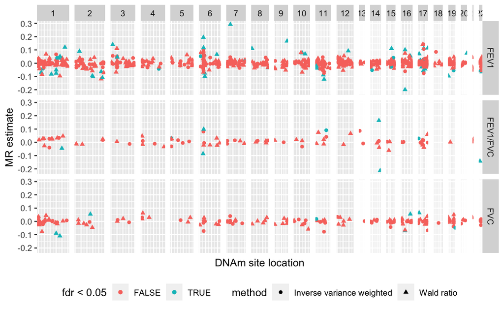

```r
ggplot(res %>% filter(method %in% c("Inverse variance weighted", "Wald ratio")), aes(x=cpgpos, y=b)) +
  geom_point(aes(colour=fdr < 0.05, shape=method)) +
  facet_grid(outcome ~ cpgchr, scale="free_x", space="free_x") +
  theme(axis.text.x=element_blank(), axis.ticks.x=element_blank(), legend.position="bottom") +
  labs(x="DNAm site location", y="MR estimate")
ggsave("fig_mr_miami.pdf", width=10, height=5)
```

There are some associations here that are stronger than expected by chance e.g. what fraction of the MR results have an FDR < 0.05? (5% of these are expected to be false positives). And what fraction of MR results have a p-value < 0.05? (expect 0.05 under the null hypothesis of no associations)

```r
res %>%
  group_by(outcome) %>%
  summarise(
    n=n(),
    prop_fdr=sum(fdr < 0.05)/n(),
    prop_nominal=sum(pval < 0.05)/n()
  )
```

| outcome | n | prop_fdr | prop_nominal |
| --- | --- | --- | --- |
| FEV1 | 688 | 0.08720930 | 0.2005814 |
| FEV1/FVC | 91 | 0.09890110 | 0.2967033 |
| FVC | 173 | 0.05202312 | 0.1156069 |

## 3. Test if FEV1(EWAS) related mQTLs are enriched for low p-values in lung function GWAS

Is this number of significant mQTLs in lung function more than expected by chance (given that lung function is polygenic and that mQTLs are enriched for high LD, intermediate MAF etc)? Compare the test statistics of the lung function mQTLs against the rest of the mQTLs in GoDMC, adjusting for SNP variance and LD scores.

```r
mqtl_snps <- unique(clumped$rsid) %>% na.exclude()
length(mqtl_snps)
```

```
[1] 217878
```

Extract all mQTLs from FEV1

```r
case_when(
    y == "ebi-a-GCST007432" ~ "FEV1",
    y == "ebi-a-GCST007431" ~ "FEV1/FVC",
    y == "ebi-a-GCST007429" ~ "FVC",
    TRUE ~ ""
  )
```

```
  [1] "FVC"      "FVC"      "FEV1"     "FEV1"     "FEV1/FVC" "FEV1/FVC" "FEV1"     "FEV1"     "FVC"      "FEV1/FVC" "FEV1"     "FEV1"
 [13] "FVC"      "FEV1"     "FEV1/FVC" "FEV1/FVC" "FEV1/FVC" "FEV1/FVC" "FEV1"     "FEV1"     "FEV1"     "FEV1"     "FEV1"     "FVC"
 [25] "FVC"      "FEV1"     "FEV1/FVC" "FVC"      "FEV1/FVC" "FEV1"     "FEV1/FVC" "FVC"      "FEV1"     "FEV1"     "FEV1/FVC" "FVC"
 [37] "FEV1/FVC" "FEV1/FVC" "FEV1/FVC" "FVC"      "FEV1"     "FEV1"     "FEV1/FVC" "FEV1"     "FVC"      "FVC"      "FVC"      "FEV1"
 [49] "FVC"      "FVC"      "FVC"      "FEV1"     "FEV1/FVC" "FEV1"     "FEV1"     "FEV1/FVC" "FEV1/FVC" "FEV1"     "FVC"      "FEV1"
 [61] "FEV1/FVC" "FEV1"     "FEV1/FVC" "FVC"      "FVC"      "FVC"      "FEV1/FVC" "FVC"      "FEV1"     "FVC"      "FEV1/FVC" "FVC"
 [73] "FVC"      "FVC"      "FVC"      "FEV1/FVC" "FVC"      "FEV1"     "FEV1"     "FEV1"     "FEV1/FVC" "FVC"      "FEV1/FVC" "FEV1/FVC"
 [85] "FVC"      "FVC"      "FEV1/FVC" "FEV1"     "FEV1/FVC" "FVC"      "FEV1"     "FEV1/FVC" "FEV1"     "FEV1"     "FEV1/FVC" "FEV1"
 [97] "FVC"      "FEV1"     "FVC"      "FEV1/FVC"
```

What fraction of all GoDMC mQTLs associate with FEV1?

```r
prop.table(table(mqtl_fev1$pval.outcome < 0.05))
```

```
    FALSE      TRUE
0.7988952 0.2011048
```

Compares to FEV1 mQTLs

```r
prop.table(table(mqtl_fev1$pval.outcome[mqtl_fev1$SNP %in% dat$SNP] < 0.05))
```

```
    FALSE      TRUE
0.7519651 0.2480349
```

Hypothesis - lung function EWAS related mQTLs are more likely to relate to lung function GWAS than all other known mQTLs

Obtain allele frequency and LD score info for the mQTLs

Perform the analysis of

$$FEV1_{GWAS} \sim mQTL_{EWAS} + LDscore + Var(SNP)$$

i.e. if we denote an $mQTL_{EWAS}$ to be for `DNAm sites associated with FEV1 in EWAS` vs `all other DNAm sites`, then does that predict lower GWAS p-values for FEV1?

```r
afl2$fev1 <- as.numeric(afl2$rsid %in% subset(outcome_dat, outcome=="FEV1")$SNP)
afl2$fvc <- as.numeric(afl2$rsid %in% subset(outcome_dat, outcome=="FVC")$SNP)
afl2$fev1fvc <- as.numeric(afl2$rsid %in% subset(outcome_dat, outcome=="FEV1/FVC")$SNP)
table(afl2$fev1)
```

```
     0      1
214010   1050
```

```r
table(afl2$fvc)
```

```
     0      1
214805    255
```

```r
table(afl2$fev1fvc)
```

```
     0      1
214932    128
```

```r
str(enr_dat)
```

```
tibble[,31] [195,519 × 31] (S3: tbl_df/tbl/data.frame)
 $ AF.AFR      : num [1:195519] 0.645 0.986 0.473 0.562 0.629 ...
 $ N.AFR       : int [1:195519] 661 661 661 661 661 661 661 661 661 661 ...
 $ L2.AFR      : num [1:195519] 98.9 36.6 47.7 56 37.1 ...
 $ AF.AMR      : num [1:195519] 0.836 0.87 0.504 0.349 0.608 ...
 $ N.AMR       : int [1:195519] 347 347 347 347 347 347 347 347 347 347 ...
 $ L2.AMR      : num [1:195519] 110.2 87.7 110.2 64.8 118.8 ...
 $ AF.EAS      : num [1:195519] 0.716 0.765 0.251 0.301 0.326 ...
 $ N.EAS       : int [1:195519] 504 504 504 504 504 504 504 504 504 504 ...
 $ L2.EAS      : num [1:195519] 95.9 87.9 50.1 48.5 41.2 ...
 $ AF.EUR      : num [1:195519] 0.739 0.767 0.604 0.3 0.406 ...
 $ N.EUR       : int [1:195519] 503 503 503 503 503 503 503 503 503 503 ...
 $ L2.EUR      : num [1:195519] 85.5 81.3 85.7 78.3 62.6 ...
 $ AF.SAS      : num [1:195519] 0.706 0.718 0.363 0.347 0.435 ...
 $ N.SAS       : int [1:195519] 489 489 489 489 489 489 489 489 489 489 ...
```

[output cut: 17 more lines]

| outcome | incl6 | EWAS mQTLs | Total mQTLs | b | se | pval |
| --- | --- | --- | --- | --- | --- | --- |
| fev1 | TRUE | 985 | 195519 | 1.3853171 | 0.3029455 | 4.814845e-06 |
| fvc | TRUE | 241 | 195519 | 0.5123931 | 0.4602106 | 2.655430e-01 |
| fev1fvc | TRUE | 121 | 195519 | 1.2063134 | 1.1424344 | 2.910084e-01 |
| fev1 | FALSE | 885 | 178023 | 1.0885315 | 0.2077537 | 1.611703e-07 |
| fvc | FALSE | 223 | 178023 | 0.1440737 | 0.3996082 | 7.184457e-01 |
| fev1fvc | FALSE | 108 | 178023 | 1.9861349 | 0.7232141 | 6.028476e-03 |

This indicates that mQTLs for FEV1 EWAS hits associate more strongly than all other mQTLs - i.e. the EWAS is picking up DNAm sites that capture some sort of FEV1 regulatory function.

Also try binarising the FEV1 GWAS test statistic (i.e. is the test statistic for FEV1 GWAS p < 0.05)

```r
enr_dat$sig <- enr_dat$fval_fev1 > qf(0.05, 1, 300000, low=F)
model2 <- summary(glm(sig ~ fev1 + L2.EUR + snpvar, enr_dat %>% filter(chrom != 6), family="binomial"))
model2
```

```
Call:
glm(formula = sig ~ fev1 + L2.EUR + snpvar, family = "binomial",
    data = enr_dat %>% filter(chrom != 6))

Deviance Residuals:
    Min       1Q   Median       3Q      Max
-3.4067  -0.6860  -0.6011  -0.5050   2.1106

Coefficients:
              Estimate Std. Error z value Pr(>|z|)
(Intercept) -2.151e+00  1.550e-02 -138.77  < 2e-16 ***
fev1         3.073e-01  8.004e-02    3.84 0.000123 ***
L2.EUR       1.441e-03  4.399e-05   32.77  < 2e-16 ***
snpvar       3.198e+00  8.336e-02   38.36  < 2e-16 ***
---
Signif. codes:  0 ‘***’ 0.001 ‘**’ 0.01 ‘*’ 0.05 ‘.’ 0.1 ‘ ’ 1

(Dispersion parameter for binomial family taken to be 1)

    Null deviance: 171916  on 178022  degrees of freedom
Residual deviance: 168514  on 178019  degrees of freedom
AIC: 168522

Number of Fisher Scoring iterations: 4
```

Similar result - an mQTL for an FEV1 associated CpG is 1.36 times more likely to associate with FEV1 than any other mQTL.

## 4. Test if MR analyses support causal influence of DNAm on lung function

The MR results indicate that the FEV1 EWAS is capturing DNAm sites that are genetically influenced by genetic factors that also influence FEV1. One model is that there is a causal path (vertical pleiotropy)

```
G -> DNAm -> FEV1
```

Another model is horizontal pleiotropy

```
DNAm <- G -> FEV1
```

Under the vertical pleiotropy model, we would expect that the effect estimates of DNAm on FEV1 are consistent when estimated using different instruments for DNAm. Many of the DNAm sites do have multiple independent instruments, so we can try to perform this analysis.

We will formulate the analysis by hypothesising that the IVW association for `DNAm -> FEV1` is substantially stronger when combined across all instruments, than if we use any one instrument alone

```r
str(comparison)
```

[output not shown]

[output cut: 57 more lines]

[output not shown]

```r
group_by(comparison, outcome) %>%
  summarise(prop=sum(minpval > ivwpval)/ n())
```

| outcome | prop |
| --- | --- |
| FEV1 | 0.1710526 |
| FEV1/FVC | 0.2857143 |
| FVC | 0.1666667 |

We find 75 instances out of 417 in which the IVW association is stronger than the strongest Wald ratio. However, looking at the results these are very modest differences. To test if this is more than we’d expect by chance, shuffle the SNPs across DNAm sites and re-estimate the joint effects - is 75 more than we’d expect by chance?

```r
set.seed(12345)
nshuf <- 10
l <- list()
comparison_shuffle <- lapply(1:nshuf, function(i)
{
  message(i)
  shuffle <- sample(1:nrow(dat))
  dat2 <- dat
  dat2$exposure <- dat2$exposure[shuffle]
  dat2$id.exposure <- dat2$id.exposure[shuffle]
  res3 <- mr_singlesnp(dat2, all_method="mr_ivw")
  mcpg <- filter(res3, grepl("All", SNP))$exposure %>% unique

  comparison_shuffle <- res3 %>%
    filter(exposure %in% mcpg) %>%
    filter(!is.na(p)) %>%
    group_by(exposure, outcome) %>%
    do({
      x <- .
      t1 <- x %>%
        filter(!grepl("All", SNP)) %>%
        {tibble(exposure=.$exposure[1], minpval=min(.$p), n=nrow(.))}
      t2 <- x %>%
        filter(grepl("All", SNP)) %>%
        {tibble(exposure=.$exposure[1], ivwpval=.$p[1])}
      inner_join(t1, t2, by="exposure")
    })
  mutate(comparison_shuffle, perm=i) %>% return()
})
```

```
1
```

```
|===================================================================================================================== |100% ~0 s remaining
|======================================================================================================================|100% ~0 s remaining
```

```
2
```

```
|===================================================================================================================== |100% ~0 s remaining
|===================================================================================================================== |100% ~0 s remaining
```

```
3
```

```
|===================================================================================================================== |100% ~0 s remaining
|===================================================================================================================== |100% ~0 s remaining
|======================================================================================================================|100% ~0 s remaining
```

```
4
```

```
|===================================================================================================================== |100% ~0 s remaining
|===================================================================================================================== |100% ~0 s remaining
|======================================================================================================================|100% ~0 s remaining
```

```
5
```

```
|===================================================================================================================== |100% ~0 s remaining
```

```
6
```

```
|===================================================================================================================== |100% ~0 s remaining
```

```
7
```

```
|===================================================================================================================== |100% ~0 s remaining
|===================================================================================================================== |100% ~0 s remaining
```

```
8
```

```
|===================================================================================================================== |100% ~0 s remaining
```

```
9
```

```
|===================================================================================================================== |100% ~0 s remaining
```

```
10
```

```
|===================================================================================================================== |100% ~0 s remaining
```

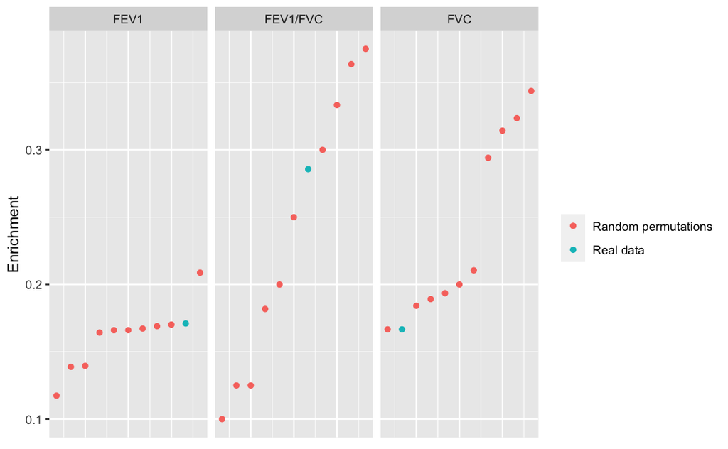

```r
bind_rows(comparison_shuffle, comparison) %>%
  group_by(perm, outcome) %>%
  summarise(enr=sum(minpval > ivwpval), count=n(), prop=enr/count) %>%
  group_by(outcome) %>%
  do({
    x <- .
    arrange(x, prop) %>% mutate(ord=1:n(), what=case_when(perm %in% 1:nshuf ~ "Random permutations", TRUE ~ "Real data"))
  }) %>%
  ggplot(., aes(x=ord, y=prop)) +
    geom_point(aes(colour=what)) +
    facet_grid(. ~ outcome) +
    labs(y="Enrichment", colour=NULL, x=NULL) +
    theme(axis.text.x=element_blank(), axis.ticks.x=element_blank())
ggsave("fig_mr_enrichment.pdf")
```

Here we see that the rate of stronger associations due to combining across DNAm sites is no more than expected by chance under a model of no causality.

## 5. Colocalisation

The MR analysis doesn’t necessarily support a causal role of DNAm on FEV1, however this analysis could be expanded by performing colocalisation of DNAm and FEV1 at the mQTLs that genetically associate with FEV1.

Determine list of DNAm-SNP sets to perform coloc on

```r
tocoloc <- res2 %>%
  filter(!grepl("All", SNP)) %>%
  mutate(fdr = p.adjust(p, "fdr")) %>%
  filter(fdr < 0.05)
save(tocoloc, file="tocoloc.rdata")
```

Obtain regional mQTL genetic effects from GoDMC API

```r
o <- lapply(unique(tocoloc$exposure), function(cpg)
  {
    o <- POST("http://api.godmc.org.uk/v0.1/query", body = list(cpgs=cpg), encode = "json")
    content(o) %>% lapply(., as_tibble) %>% bind_rows
  })
```

Organise regional data

```r
cpgregions <- o %>% bind_rows() %>%
  separate(name, into=c("snpchr", "snppos", "snptype"), sep=":") %>%
  mutate(
    snpchr=as.numeric(gsub("chr", "", snpchr)),
    snppos=as.numeric(snppos)
  )
str(cpgregions)
```

```
tibble[,30] [155,566 × 30] (S3: tbl_df/tbl/data.frame)
 $ a1         : chr [1:155566] "C" "G" "G" "G" ...
 $ a2         : chr [1:155566] "T" "T" "A" "A" ...
 $ allele1    : num [1:155566] 0 0 0 0 0 0 0 0 0 0 ...
 $ allele2    : num [1:155566] 0 0 0 0 0 0 0 0 0 0 ...
 $ beta_a1    : num [1:155566] -0.184 -0.183 -0.183 -0.181 -0.178 ...
 $ beta_are_a1: num [1:155566] -0.184 -0.183 -0.184 -0.181 -0.178 ...
 $ chunk      : int [1:155566] 208 208 208 208 208 208 208 208 208 208 ...
 $ cistrans   : int [1:155566] 1 1 1 1 1 1 1 1 1 1 ...
 $ clumped    : int [1:155566] 1 0 0 0 0 0 0 0 0 0 ...
 $ cpg        : chr [1:155566] "cg05284742" "cg05284742" "cg05284742" "cg05284742" ...
 $ direction  : chr [1:155566] "+++++++++++-+-+++++++++++-++++++++++" "+++++++++++-+++++++++++++-++++++++++" "+++++++++++-+++++++++++++-+?++++++++" "+++++++?+++-++++++++++++?+++++++++++" ...
 $ freq_a1    : num [1:155566] 0.11 0.11 0.109 0.114 0.114 ...
 $ freq_se    : num [1:155566] 0.0156 0.0152 0.0151 0.0126 0.0129 0.0157 0.0126 0.0135 0.0131 0.0152 ...
 $ hetchisq   : num [1:155566] 62.7 62.7 63.6 58.5 62.3 ...
```

[output cut: 16 more lines]

Perform colocalisation for each DNAm-SNP set that associated with FEV1 GWAS

Distribution of P(H4)

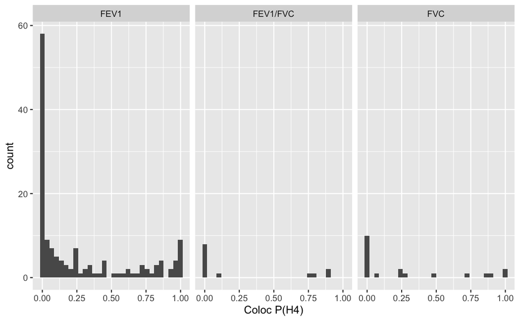

```r
ggplot(colocres, aes(x=h4)) + geom_histogram() +
  facet_grid(. ~ outcome) +
  labs(x="Coloc P(H4)")
ggsave("fig_coloc.pdf")
```

How many colocalise at p(h4) > 0.8?

```r
table(colocres$h4 > 0.8, colocres$outcome)
```

```
        FEV1 FEV1/FVC FVC
  FALSE  120       11  16
  TRUE    22        2   4
```

In regions of very long LD e.g. MHC region, colocalisation is difficult to interpret. This is because colocalisation aims to determine if two traits share a causal variant. However, if the region has extended LD then there will be a very large number of potential causal variants in high LD with each other, and it’s possible that the causal variant for DNAm is different to the causal variant for FEV1 and this will not be detectable by coloc.

```r
table(colocres$h4 > 0.8, colocres$chr)
```

```
         1  2  3  4  5  6  7  8  9 10 11 12 14 15 16 17 18 19 20 22
  FALSE 14  6  8  4  4 40  4  5  1  5 12  1  5  6  8 14  1  2  3  4
  TRUE   3  1  2  1  0 11  0  0  0  1  2  0  0  0  4  2  0  0  1  0
```

Here are the results that colocalise that are not on chromosome 6

```r
colocres %>%
  filter(chr !=6 & h4 > 0.8)
```

| rsid | cpg | chr | pos | outcome | h4 |
| --- | --- | --- | --- | --- | --- |
| rs1180330 | cg08876103 | 1 | 40011645 | FEV1 | 0.9390846 |
| rs16957489 | cg19750657 | 16 | 67651879 | FEV1/FVC | 0.9066166 |
| rs624833 | cg07134632 | 4 | 2881256 | FEV1 | 0.8316514 |
| rs17885031 | cg14914442 | 10 | 81696091 | FEV1 | 0.9305163 |
| rs199441 | cg24477401 | 17 | 44773783 | FEV1 | 0.9857093 |
| rs3847646 | cg13059136 | 11 | 2953723 | FVC | 0.8446159 |
| rs3809627 | cg02508743 | 16 | 30103160 | FEV1/FVC | 0.9094522 |
| rs1463728 | cg20912205 | 3 | 49647404 | FEV1 | 0.9884331 |
| rs2123344 | cg20811755 | 17 | 46339612 | FEV1 | 0.8694983 |
| rs56096139 | cg27093918 | 16 | 69563412 | FEV1 | 0.9467952 |

[output cut: 7 more lines]

```r
save(colocres, file="colocres.rdata")
```

## Bringing it together

1. Coloc
2. MR evidence from multiple variants?

```r
colocmrres <- left_join(
  tocoloc %>% select(outcome, exposure, SNP, b, se, pval=p),
  # Remove MHC
  colocres %>% filter(!(chr == 6 & pos > 25392021 & pos < 33392022)),
  by=c("SNP"="rsid", "exposure"="cpg", "outcome")) %>% select(outcome, exposure, SNP, chr, pos, everything()) %>% arrange(outcome, desc(h4)) %>% mutate(h4=round(h4, 2))
dim(colocmrres)
```

```
[1] 201   9
```

```r
colocmrres
```

| outcome | exposure | SNP | chr | pos | b | se | pval | h4 |
| --- | --- | --- | --- | --- | --- | --- | --- | --- |
| FEV1 | cg17724175 | rs12401456 | 1 | 150204405 | 0.04073059 | 0.005537930 | 1.911578e-13 | 1.00 |
| FEV1 | cg12269535 | rs6941411 | 6 | 43107943 | -0.09932861 | 0.020222591 | 9.026033e-07 | 1.00 |
| FEV1 | cg20912205 | rs1463728 | 3 | 49647404 | 0.08188638 | 0.012418788 | 4.288536e-11 | 0.99 |
| FEV1 | cg24477401 | rs199441 | 17 | 44773783 | 0.25477588 | 0.018723687 | 3.631659e-42 | 0.99 |
| FEV1 | cg21932231 | rs62136162 | 2 | 36660581 | 0.08971758 | 0.017313919 | 2.197334e-07 | 0.98 |
| FEV1 | cg27093918 | rs56096139 | 16 | 69563412 | 0.05429001 | 0.006749569 | 8.732370e-16 | 0.95 |
| FEV1 | cg08876103 | rs1180330 | 1 | 40011645 | -0.04039227 | 0.008872290 | 5.297900e-06 | 0.94 |
| FEV1 | cg14914442 | rs17885031 | 10 | 81696091 | -0.13215607 | 0.031690485 | 3.043154e-05 | 0.93 |
| FEV1 | cg06568490 | rs9872360 | 3 | 13811824 | 0.14064719 | 0.037808384 | 1.992228e-04 | 0.88 |
| FEV1 | cg05654980 | rs11807942 | 1 | 224560371 | 0.12005932 | 0.024184612 | 6.895437e-07 | 0.87 |

[output cut: 191 more lines]

Do any of the colocalising signals also have another variant?

```r
temp <- subset(colocmrres, h4 >= 0.8)
dat_coloc <- subset(dat, paste(outcome, exposure) %in% paste(temp$outcome, temp$exposure))
mr_coloc <- mr(dat_coloc) %>% suppressMessages()
het_coloc <- mr_heterogeneity(dat_coloc, method_list="mr_ivw") %>% suppressMessages()
```

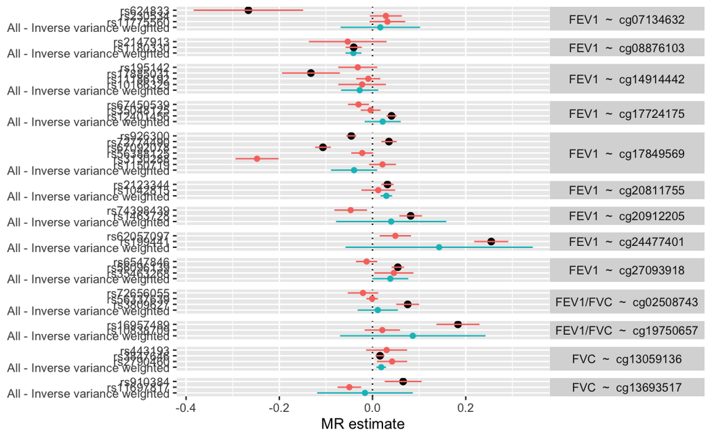

```r
mr_coloc_ss <- mr_singlesnp(dat_coloc %>% filter(paste(exposure, outcome) %in% paste(het_coloc$exposure, het_coloc$outcome)), all_method = "mr_ivw")
mr_coloc_ss <- left_join(mr_coloc_ss, colocres, by=c("SNP"="rsid", "exposure"="cpg", "outcome")) %>%
  mutate(coloc_sig = h4 >= 0.8)

ggplot(subset(mr_coloc_ss), aes(x=b, y=SNP)) +
  geom_vline(xintercept=0, linetype="dotted") +
  geom_point(aes(colour=grepl("All", SNP))) +
  geom_point(data=subset(mr_coloc_ss, coloc_sig), colour="black", size=2) +
  geom_errorbarh(aes(xmin=b-1.96*se, xmax=b+1.96*se, colour=grepl("All", SNP)), height=0) +
  facet_grid(paste(outcome, " ~ ", exposure) ~ ., scale="free_y", space="free_y") +
  labs(y=NULL, x="MR estimate") +
  theme(legend.position="none", strip.text.y=element_text(angle=0))
ggsave("fig_coloc_mr.pdf", height=8, width=7)
```

## Tables

MR and coloc results

```r
write.csv(colocmrres, "tab_colocmrres.csv")
```

mQTL enrichment results

```r
write.csv(model_res, "tab_mqtl_enrichment.csv")
```

Multiple instrument MR and heterogeneity

```r
inner_join(res, het_coloc, by=c("exposure", "outcome")) %>%
  select(exposure, outcome, nsnp, b, se, pval, Q, Q_pval) %>%
  arrange(outcome) %>%
  write.csv(., "tab_mr_het.csv")
```